# Exploratory Data Analysis

Fernando de Oliveira Junior

3/15/2020

### We are going to perform a EDA on Spotify data

##### First of all, let’s see our databases:

##### 1. `All songs`: have features for all 71283 songs generated in `2020-03-14`.

```r
summary(all_songs)
```

```
##       id             danceability       energy            key
##  Length:71283       Min.   :0.000   Min.   :0.0000   0      : 8600
##  Class :character   1st Qu.:0.432   1st Qu.:0.3380   7      : 7976
##  Mode  :character   Median :0.570   Median :0.5940   2      : 7546
##                     Mean   :0.554   Mean   :0.5565   9      : 6860
##                     3rd Qu.:0.695   3rd Qu.:0.7960   1      : 6808
##                     Max.   :0.985   Max.   :1.0000   5      : 6035
##                                                      (Other):27458
##     loudness       mode       speechiness       acousticness
##  Min.   :-60.000   0:25713   Min.   :0.00000   Min.   :0.0000
##  1st Qu.:-12.204   1:45570   1st Qu.:0.03570   1st Qu.:0.0394
##  Median : -8.067             Median :0.04680   Median :0.2850
##  Mean   :-10.120             Mean   :0.08127   Mean   :0.3938
##  3rd Qu.: -5.613             3rd Qu.:0.07980   3rd Qu.:0.7580
##  Max.   :  3.018             Max.   :0.96300   Max.   :0.9960
##
##  instrumentalness      liveness         valence           tempo
##  Min.   :0.000000   Min.   :0.0000   Min.   :0.0000   Min.   :  0.00
##  1st Qu.:0.000000   1st Qu.:0.0952   1st Qu.:0.2280   1st Qu.: 95.34
##  Median :0.000391   Median :0.1180   Median :0.4340   Median :118.92
##  Mean   :0.220056   Mean   :0.1847   Mean   :0.4499   Mean   :118.57
##  3rd Qu.:0.391000   3rd Qu.:0.2150   3rd Qu.:0.6640   3rd Qu.:137.84
##  Max.   :1.000000   Max.   :0.9980   Max.   :1.0000   Max.   :244.16
##
##   duration_ms      time_signature track.popularity track.album.id
##  Min.   :  10750   0:   95        Min.   :  0.00   Length:71283
##  1st Qu.: 182372   1:  737        1st Qu.: 22.00   Class :character
##  Median : 217416   3: 6820        Median : 38.00   Mode  :character
##  Mean   : 242068   4:62225        Mean   : 36.17
##  3rd Qu.: 266040   5: 1406        3rd Qu.: 51.00
##  Max.   :4423000                  Max.   :100.00
##
##  track.album.release_date track.album.release_date_precision
##  Min.   :1949-12-01       Length:71283
##  1st Qu.:2012-03-28       Class :character
##  Median :2017-11-10       Mode  :character
##  Mean   :2013-08-18
##  3rd Qu.:2019-07-07
##  Max.   :2020-04-15
##  NA's   :4292
##     is_hit
##  Hit   : 1293
##  No Hit:69990
##
##
##
##
##
```

##### As we can see there’s only NA’s in `track.album.release_date`

##### 2. `Most popular`: have features for the 200 most popular songs in Brazil each day since Jan 2017

```r
summary(most_popular)
```

```
##       date                 ano            mes              id
##  Min.   :2017-01-01   Min.   :2017   Min.   : 1.000   Length:232800
##  1st Qu.:2017-10-22   1st Qu.:2017   1st Qu.: 3.000   Class :character
##  Median :2018-08-09   Median :2018   Median : 6.000   Mode  :character
##  Mean   :2018-08-08   Mean   :2018   Mean   : 6.228
##  3rd Qu.:2019-05-27   3rd Qu.:2019   3rd Qu.: 9.000
##  Max.   :2020-03-13   Max.   :2020   Max.   :12.000
##
##   danceability        energy            key           loudness
##  Min.   :0.2090   Min.   :0.0217   0      :28003   Min.   :-25.166
##  1st Qu.:0.6050   1st Qu.:0.5780   11     :24965   1st Qu.: -6.432
##  Median :0.6820   Median :0.7240   1      :24470   Median : -5.042
##  Mean   :0.6837   Mean   :0.6982   7      :21695   Mean   : -5.297
##  3rd Qu.:0.7760   3rd Qu.:0.8320   2      :19953   3rd Qu.: -3.685
##  Max.   :0.9740   Max.   :0.9990   6      :19888   Max.   :  0.612
##                                    (Other):93826
##  mode        speechiness      acousticness      instrumentalness
##  0: 88027   Min.   :0.0232   Min.   :0.000034   Min.   :0.0000000
##  1:144773   1st Qu.:0.0438   1st Qu.:0.106000   1st Qu.:0.0000000
##             Median :0.0686   Median :0.279000   Median :0.0000000
##             Mean   :0.1066   Mean   :0.323481   Mean   :0.0059329
##             3rd Qu.:0.1280   3rd Qu.:0.505000   3rd Qu.:0.0000018
##             Max.   :0.8410   Max.   :0.986000   Max.   :0.9260000
##
##     liveness         valence           tempo        duration_ms
##  Min.   :0.0197   Min.   :0.0391   Min.   : 48.7   Min.   : 37640
##  1st Qu.:0.1010   1st Qu.:0.4730   1st Qu.:103.0   1st Qu.:167500
##  Median :0.1670   Median :0.6430   Median :126.2   Median :187133
##  Mean   :0.3058   Mean   :0.6094   Mean   :127.1   Mean   :194254
##  3rd Qu.:0.4010   3rd Qu.:0.7680   3rd Qu.:146.1   3rd Qu.:210960
##  Max.   :0.9900   Max.   :0.9750   Max.   :212.1   Max.   :737705
##
##  time_signature track.popularity track.album.id
##  1:    65       Min.   :  0.00   Length:232800
##  3:  5616       1st Qu.: 49.00   Class :character
##  4:221133       Median : 61.00   Mode  :character
##  5:  5986       Mean   : 54.46
##                 3rd Qu.: 70.00
##                 Max.   :100.00
##
##  track.album.release_date track.album.release_date_precision
##  Min.   :1957-12-02       Length:232800
##  1st Qu.:2017-04-20       Class :character
##  Median :2018-02-23       Mode  :character
##  Mean   :2017-11-01
##  3rd Qu.:2018-11-23
##  Max.   :2020-03-13
##  NA's   :1063
##      ano_mes
##  Jan 2017:  6200
##  Mar 2017:  6200
##  Jul 2017:  6200
##  Aug 2017:  6200
##  Oct 2017:  6200
##  Dec 2017:  6200
##  (Other) :195600
```

### Now we are going to state some questions to guide our EDA:

### 1. How is the popularity index calculated?

> The value will be between 0 and 100, with 100 being the most popular. The popularity is calculated by algorithm and is based, in the most part, on the total number of plays the track has had and how recent those plays are.

### 2. How is the popularity distributed

> it has a lot of songs with realy small popularity index and, for other songs, it follows a normal distribuition with a mean of 36.2

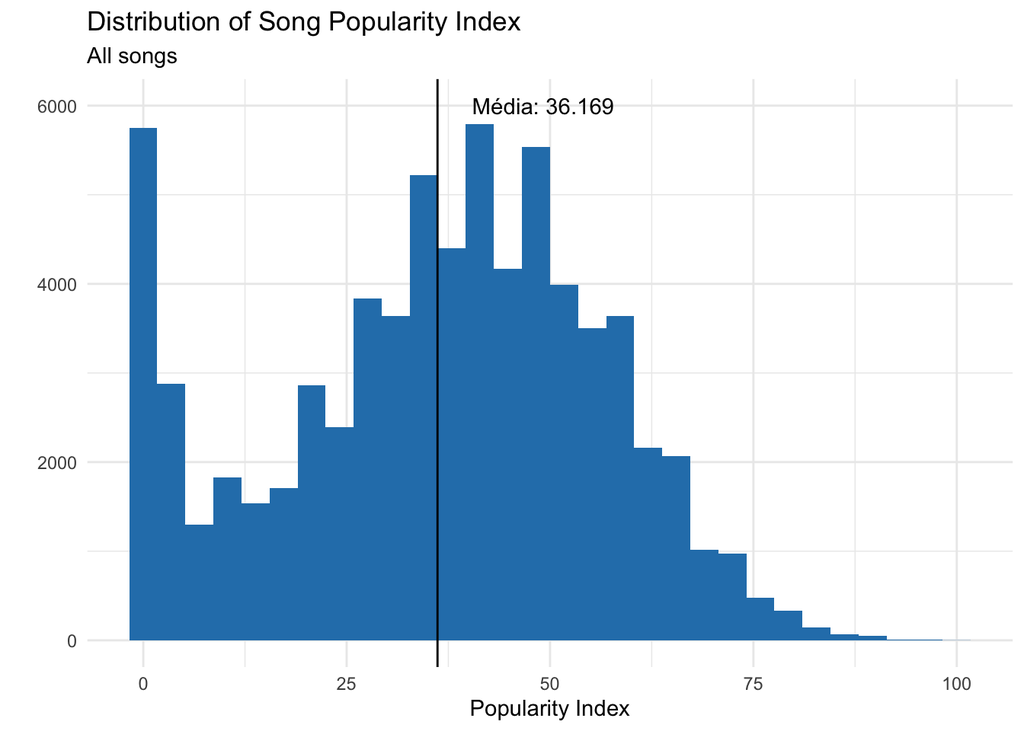

### 3. How is the popularity distributed for the songs that were on the 200 charts at any moment since Jan 2017?

> it has a lot of songs with realy small popularity index and, for other songs, it follows a normal distribuition with a mean of 49.5

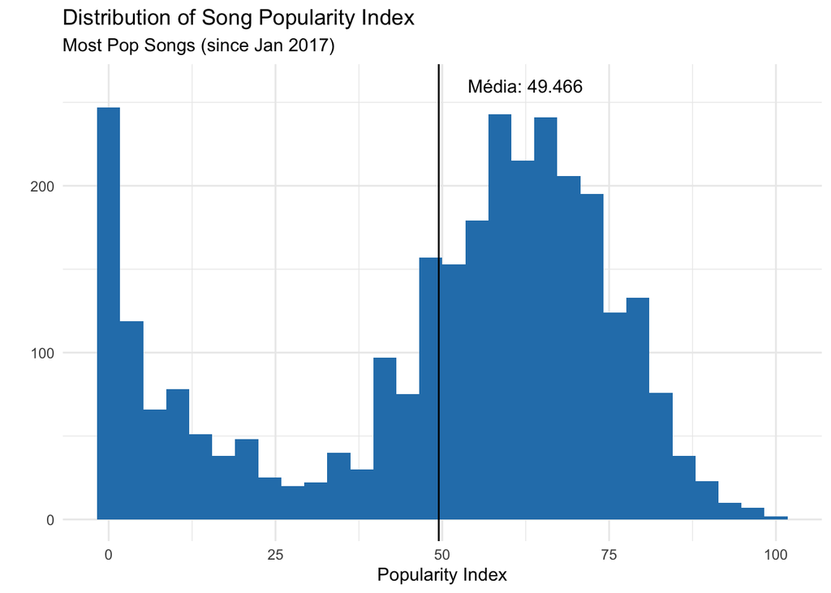

### 4. Can we compare, visually, the two distributions?

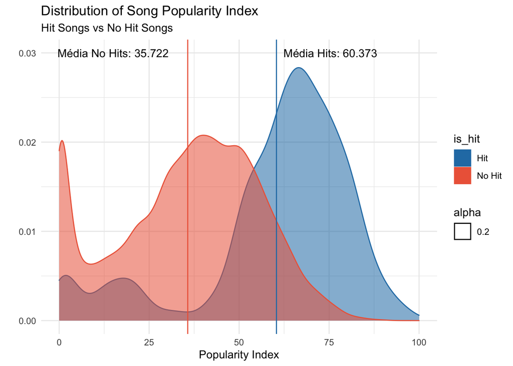

### 5. Is there any correlations between song features and popularity index?

> There is no correlation between the features of the songs and popularity, which makes sense, since popularity index is based on changeable parameters

### 5.1 For all songs

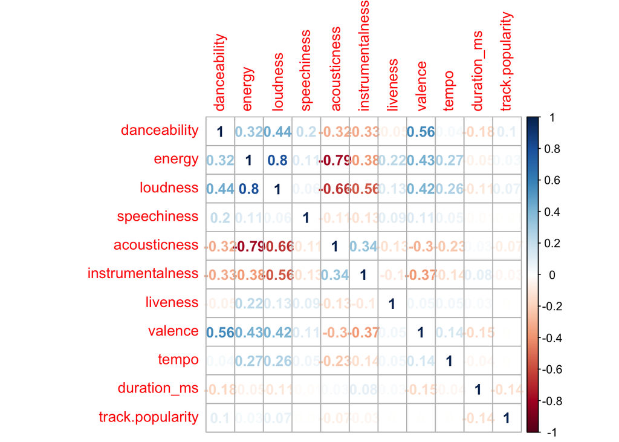

### 5.2 For the most popular songs

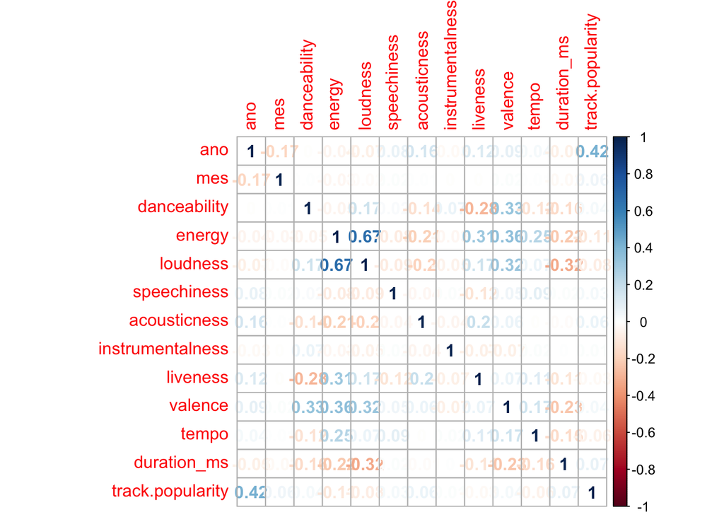

### 6. From 5, do the evolution of features for the most popular songs correlates with popularity over time? It would make sense, if the taste of people is changing over time

> From 6.1 we can say that the popular songs from the past don’t, necesseraly have higher popularity today. Acctualy, what we observe is that it’s lower than those from the songs that are more popular nowadays, which make sense by the way the index is calculated

> From 6.2 we can observe that the evolution of the features from the most popular song in each month is highly correlated with the popularity index. Threrefore, it can be used in order to create the model to infer the index.

### 6.1 How does popularity distribuition evolve for those songs?

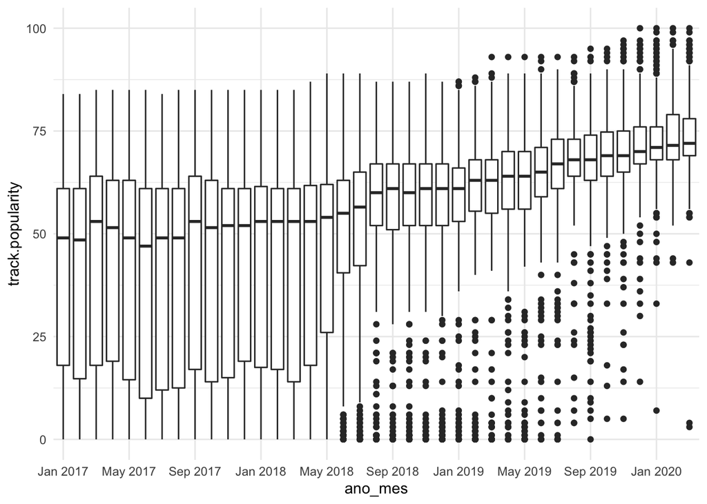

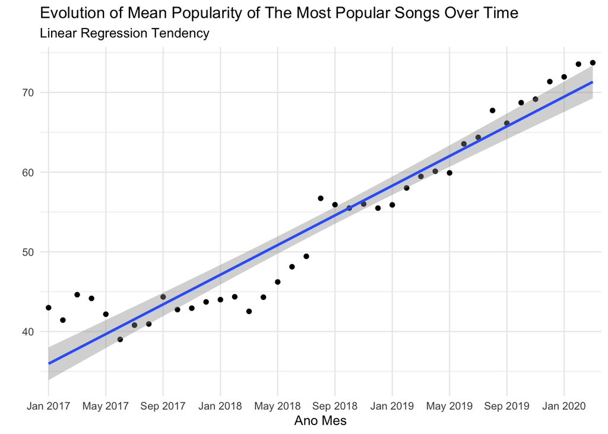

### 6.2 How is the correlation between the evolution of popularity index and the most popular songs?

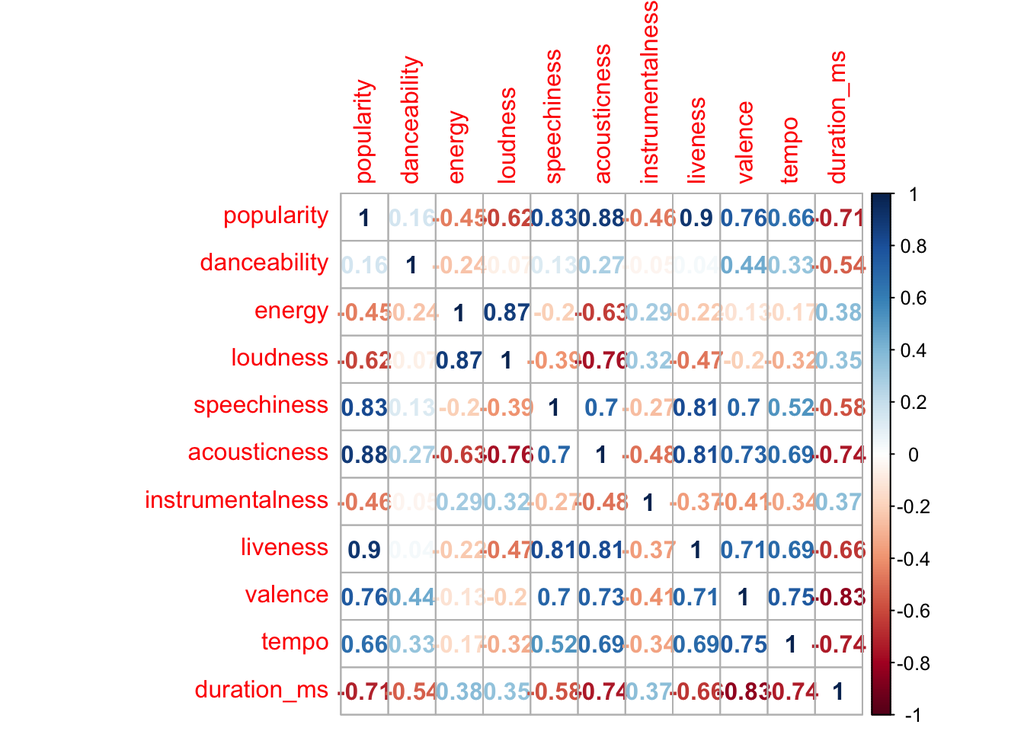

> From 7 we can observe that, on average, each month has 307 songs at the top 200 raking.

### 7. How many popular (Top 200) songs are there each month?

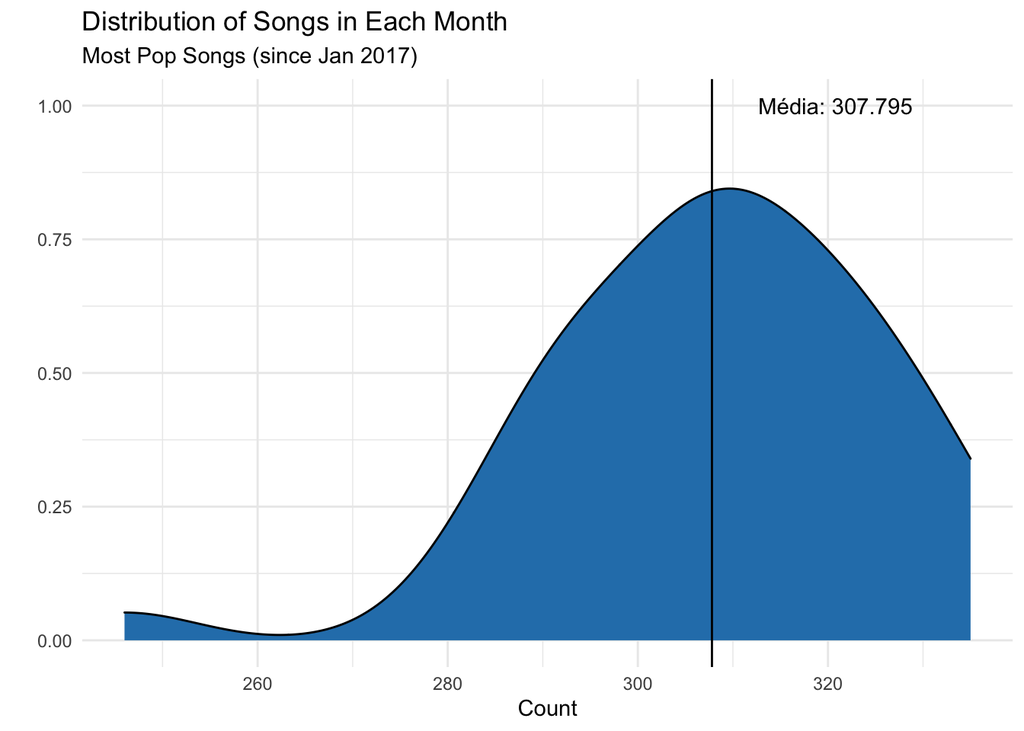

> From 8.1, there are some outliers and the distribuition is assimetrical for the amount of days a song remains at the top 200 ranking

### 8.1. How many days a song remain at the top 200?

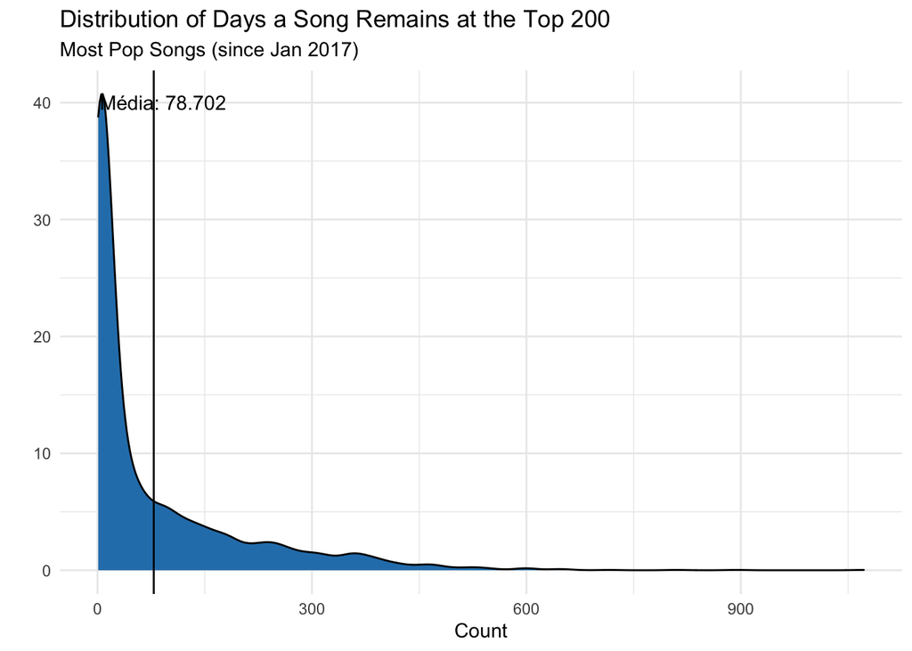

> From 8.2, we are going to drop observations above the percentil 97% (387 days)

### 8.2. Analysing distribuition in order to remove outliers

```
##      0%     25%     50%     75%     90%     91%     92%     93%     94%
##    1.00    3.00   18.00  112.00  251.30  266.87  282.44  302.00  321.16
##     95%     96%     97%     98%     99%    100%
##  349.15  364.44  387.00  425.86  491.87 1072.00
```

> From 8.3, we can observe that the distribuition is very assimetrical. There are lots of songs with few days in top 200 and a few songs with a lot of days in the top 200 ranking

### 8.3. Analysing the distribuition without outliers

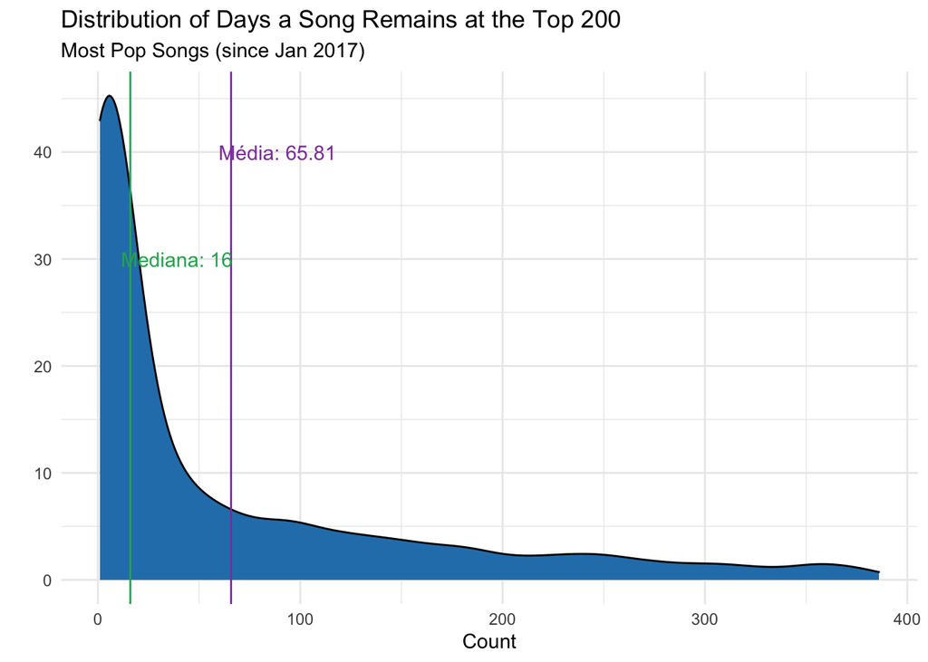

> From 9, we can see that there are, on average, 132 songs remaning popular in each month, so we could define our monthly songs to be clustered as the songs that remain on top.

### 9. How many songs remain at the top 200 each month?

```
##      songs
##  Min.   :  8
##  1st Qu.:130
##  Median :134
##  Mean   :132
##  3rd Qu.:140
##  Max.   :153
```

### 10. When were songs released, considering both the populars and all other songs?

### 10.1 All Songs

```
##  track.album.release_date
##  Min.   :1949-12-01
##  1st Qu.:2012-03-28
##  Median :2017-11-10
##  Mean   :2013-08-18
##  3rd Qu.:2019-07-07
##  Max.   :2020-04-15
##  NA's   :4292
```

### 10.2 Popular Songs

```
##  track.album.release_date
##  Min.   :1957-12-02
##  1st Qu.:2017-05-26
##  Median :2018-04-18
##  Mean   :2017-06-13
##  3rd Qu.:2019-03-08
##  Max.   :2020-03-13
##  NA's   :20
```